# Daily Phone Usage: A Visual Data Story

## Introduction

This visual data story explores my daily phone usage patterns using data collected through my Google Form. I reused the same observational logging form from Project 2 and collected 20 more observations for Project 4, so the final data set contains 40 responses. The data records how many hours I used my phone each day, what I mainly used it for, and whether I used it before going to sleep.

The purpose of this story is to explore a few different aspects of my phone use. I wanted to see how my usage changed over time, whether some activities were linked to longer phone use, and whether using my phone before sleep was connected to different usage patterns. I used R, `{tidyverse}`, `{lubridate}`, and `{ggplot2}` to clean the data, create new variables, summarise patterns, and make the visualisations below.

## Daily phone usage over time

The first visualisation shows how average phone usage changed across the recorded dates.

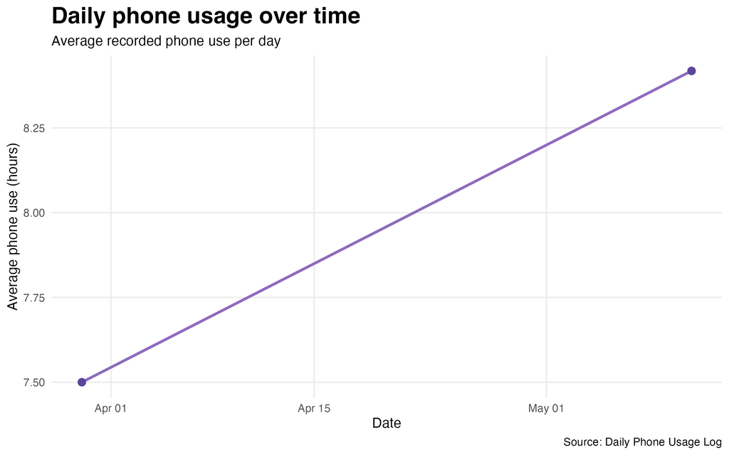

Line chart showing how average daily phone use changes across recorded dates.

This plot was created using a data frame summarised by date. I first converted the Google Form timestamp into a date-time variable using `{lubridate}`, then extracted the date and grouped the data by day. A line graph was used here because it is a good way to show change over time.

## Main purpose of phone use

The second visualisation compares average phone usage across the main purposes recorded in the form.

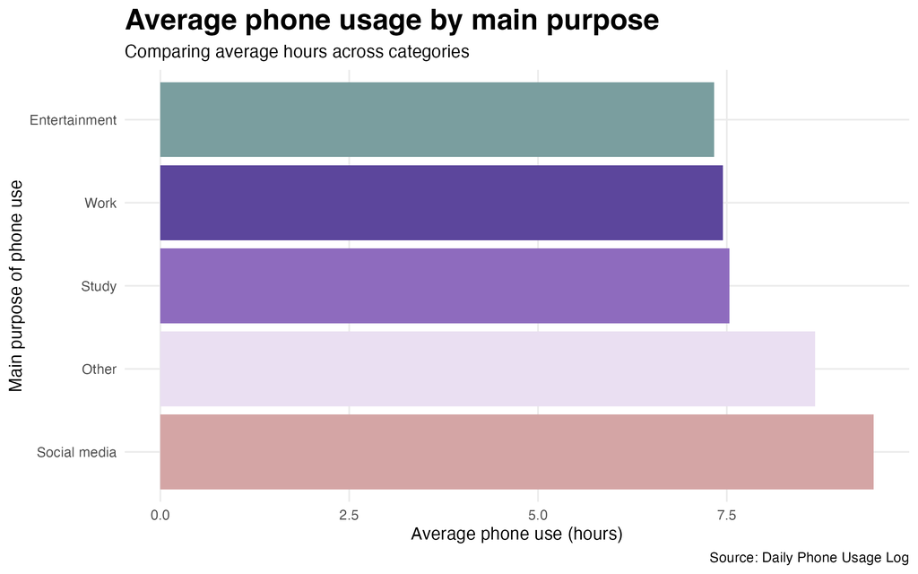

Bar chart comparing average phone use across different main purposes.

To make this plot, I grouped the data by the variable `main_use` and then calculated the average number of phone-use hours for each category. A bar chart was used because it makes it easy to compare values across categories.

The chart suggests that not all types of phone use are linked to the same amount of screen time. Some categories appear to have higher average usage than others, which implies that the purpose of phone use matters. This is useful for the visual story because it goes beyond asking how long I used my phone and instead focuses on what kinds of activities are associated with heavier use.

## Phone use before sleep

The third visualisation compares phone-use hours depending on whether I used my phone before going to sleep.

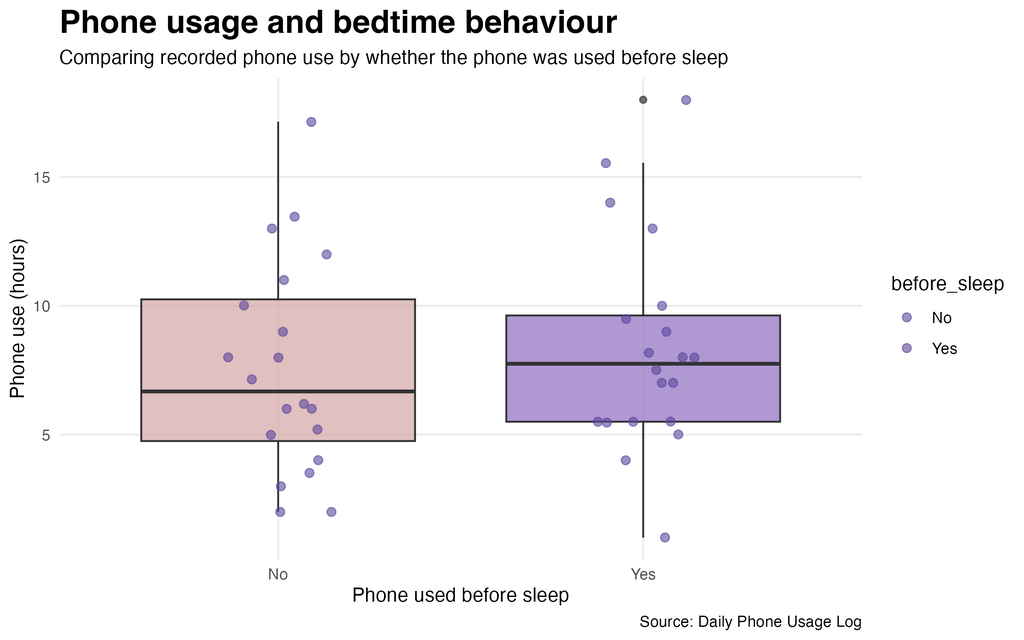

Boxplot and jitter plot comparing phone use hours for days with and without phone use before sleep.

This plot combines a boxplot and a jitter plot. The boxplot summarises the distribution of phone-use hours in each group, while the jittered points show the individual observations. This layered approach makes it easier to compare both the overall pattern and the spread of the raw data.

The graph suggests that days with phone use before sleep may be linked to different usage patterns from days without phone use before sleep. At the same time, the individual points show that there is still variation within both groups. This suggests that bedtime phone use may be related to total screen time, but it is probably not the only factor affecting it.

## What the visualisations reveal

Together, these three visualisations show that my phone use can be looked at from several different angles. The first plot focuses on change over time, the second compares the main purposes of phone use, and the third looks at phone behaviour before sleep. Each visualisation uses a different combination of variables and a different graphical approach, which helps tell a broader story rather than repeating the same message.

In terms of the grammar of graphics, I used different data frames depending on the goal of each plot. For the first two visualisations, I manipulated the data first using functions such as `mutate()`, `group_by()`, and `summarise()` to create new summary data frames. I then mapped variables to axes using `aes()` and selected geoms that matched the type of comparison I wanted to make. For the final plot, I combined raw data with summary structure by using a boxplot together with jittered points. This shows how the layered grammar of graphics can be used to communicate the same data in more meaningful ways.

## Conclusion

This visual data story shows that my daily phone usage is not just a single number. It changes over time, varies depending on the main purpose of use, and may also be related to whether I use my phone before sleep. By cleaning and restructuring the data, I was able to move from simple observations to a clearer visual explanation of my phone-use habits.

Overall, the main insight from this analysis is that phone use is shaped by both routine and behaviour. Looking only at total hours would not have shown the full picture. By using three different visualisations, I was able to show a more complete view of how, why, and when I use my phone.